# STAT 331 Portfolio

## Program Efficiency

**PE-1: I can write concise code which does not repeat itself.**

- using a single function call

```r
# Lab 4 (Question 6)
# Using %in% to filter
californiaAvocado <- avocadoMetro |>
  filter(region %in% c("LosAngeles",
                       "SanDiego",
                       "Sacramento",
                       "SanFrancisco")) |>
  select(Date, type, region, AveragePrice) |>
  pivot_wider(names_from = type, values_from = AveragePrice) |>
  group_by(region) |>
  summarise(meanConventional = mean(conventional), meanOrganic = mean(organic))
```

- `across()`

```r
# Challenge 3 (Question 5.1.1 Male vs. Female)
summary1 <- hiphop_coll |> group_by(sex) |>
  summarize(across(intl:unclassifiable, mean, na.rm = TRUE))

differences1 <- summary1 |>
  summarize(across(intl:unclassifiable, diff))

absdiff1 <- differences1 |> summarize(across(intl:unclassifiable, abs))

which.max(absdiff1)
```

**PE-2: I can write functions to reduce repetition in my code.**

**PE-3:I can use iteration to reduce repetition in my code.**

**PE-4: I can use modern tools when carrying out my analysis.**

## Data Simulation & Modeling

**DSM-1: I can simulate data from a *variety* of probability models.**

**DSM-2: I can fit a linear regression and extract necessary summary measures.**

## Revising My Thinking

Despite showing proficiency in most of the learning targets, I still face some issues such as lacking plot labels and code repetition. This can be seen in my earlier labs where I failed to put proper axis labels. There was also a lot of repeating and inefficient code in my initial Lab 3 submission. Because of proper feedback, I was able to revise my thinking and apply the feed backs I received in my future lab assignments. I use my Lab 5 Time Plot as a reference to clear and readable plots, as believe that to be my cleanest one. Additionally, after receiving the efficiency feedback in Lab 3, I began to take it into more consideration. When summarizing data across columns greater than 2, I utilize the `across()` helper to avoid repetition (this was done through a Challenge revision). I have also continued to show improvement and learning in this aspect through my Lab 4 when I used `%in%` when filtering a data set. Overall, I believe to have demonstrated a proficiency in revised thinking throughout the entirety of the course. I take each feedback from my professor and peers into account in order to avoid making the same mistakes in the future. I have also always made sure to submit a revision each week despite having only minor issues with my code.

## Peer Support & Collaboration

I believe to be highly proficient in peer support and collaboration. In the weeks of doing practice activities with my group, I have been the facilitator, team captain, recorder, and report editor. I believe to be successful in my role in all the weeks as my group and I have been successful in the task, and have established a good relationship inside and outside of the classroom. In terms of peer support, I try to respond to queries on discord when I can, but I mostly help my peers with minor questions regarding labs. I believe to have demonstrated this especially in the data cleansing portion of Lab 4. I used my knowledge gained after attending office hours to help my peers and explain to them the reason behind utilizing `semi-join()` and `anti-join()` instead of using the filter function to cleanse data. As for peer reviews, I have been specific with my comments, and also use feedback given to me to asses my peer’s task. I try to avoid giving surface level feedback, but I also mention the minor issues for better learning. An example of my favorite feedback is attached in the image below:

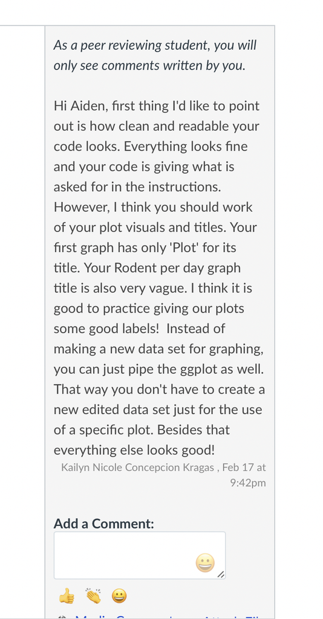

For Lab 5, I was given the same feedback with piping my ggplot to avoid creating unnecessary data sets. In this peer review, I made sure to remember the feedback, learn from it, and use it to help my peers improve their output.